# IoT or Traditional agriculture: does it really matter?

SMDS-2023-2024 Sofia Noemi Crobeddu (mtr. 2130389)

M.Sc. in Data Science

# 1. Introduction and context

In the last years, the application of advanced technologies in agriculture has seen a rapid growth, driven by the need to enhance the productivity and the sustainability in farming practices. The integration of the Internet of Things (IoT) devices in agriculture (i.e. sensors and network devices) is groundbreaking, providing farmers with real-time data on various environmental and crop-related factors. This data-driven approach facilitates more informed decision-making and optimization of agricultural processes.

This project is based on the “Advanced IoT Agriculture 2024” dataset developed from a real IoT system deployed in agricultural environments. This system allows real-time monitoring of environmental conditions within a smart greenhouse, modifying the productivity of traditional settings. The observations of the dataset describe the growth of different varieties of plants within the two types of environment. The following study analyses the effectiveness of IoT environment compared to traditional one, through the application of Bayesian models (using MCMC simulation).

## 1.1. Illustration of the dataset

The dataset mentioned before was taken from the Kaggle official website ((Abdullah 2024)). It is composed by 30000 observations and 14 variables. Data were collected by the student Mohammed Ismail Lifta of Tikrit University (Iraq), in his MSc research thesis during the academic year 2023-2024, with the collaboration of the Agricultural Laboratory and the supervision of Professor (Assistant) Wisam Dawood Abdullah, administrator of Cisco Networking Academy.

Data describe the cultivation of three radish varieties, Dutch, Syrian, and Italian, in the two greenhouse (Smart and Traditional), outlined in the introductory paragraph. They were registered in two slots between November and December 2023 ((Lafta and Abdullah 2024)).

The variables are the following ones: - **Random**: categorical identifier for each record, with modalities R1, R2 and R3 representing different random sample. - **Average Chlorophyll in Plant (ACHP)**: average value of chlorophyll content in plants. It is an important indicator of photosynthetic capacity and describes the plant’s health and the efficiency in converting light energy into chemical energy. - **Plant Height Growth Rate (PHR)**: a measure of the plant’s vertical growth rate over time. It is an important indicator to comprehend the height development. - **Average wet weight of vegetative growth (AWWGV)**: average wet weight of the vegetative parts of the plant. It is useful for assessing the water content and overall biomass of vegetative growth. - **Average plant leaf area (ALAP)**: Measure of the average leaf area, important for estimating the area available for photosynthesis. - **Average number of leaves per plant (ANPL)**: average number of leaves per plant, which can influence the photosynthetic capacity and general health of the plant. - **Average root diameter (ARD)**: average root diameter. It is an indicator of the plant’s ability to absorb water and nutrients from the soil. - **Average dry weight of roots (ADWR)**: average dry weight of the roots, indicative of root biomass after removing water content. It is useful for assessing structural and storage capacity. - **Percentage of dry matter in vegetative growth (PDMVG)**: percentage of dry matter present in the vegetative parts of the plant, reflecting the proportion of biomass that is not composed of water, that is essential for analyzing the structure and nutritional status of the plant. - **Average root length (ARL)**: average root length, which can influence the plant’s ability to explore the soil and absorb nutrients and water. - **Average wet weight of roots (AWWR)**: average wet weight of the roots, including water content, an indicator of the overall biomass and water retention capacity of roots. - **Average dry weight of vegetative plants (ADWV)**: average dry weight of the vegetative parts of the plant. It represents the structural biomass of the plant excluding water content. - **Percentage of dry matter in root growth (PDMRG)**: percentage of dry matter in plant’s roots. It is important to assess root health and functionality. - **Class**: categorical variable indicating the class to which each plant record belongs. There are 6 classes in total (SA, SB, SC, TA, TB, TC), and specifically they represents the three varieties of plants observed (A, B, C), in each type of greenhouse (Smart and Traditional).

## 1.2. Preliminary aspects

Before starting the exploratory data analysis, it is important to specify that for this project the variable Random is not taken into account since it is an identifier variable.

Moreover, for simplicity of investigations, for this work we consider only the first two varieties A (Dutch) and B (Syrian) of the plants. This decision was based, first of all, on the results reached by Mohamed Ismail Lafta and Wisam Dawood Abdullah who found strong differences between these two varieties in particular ((Lafta and Abdullah 2024)), hence this comparison could be more interesting. Then the choice was also driven by the fact that the variable Class exposes 5000 observations in each of the 6 categories, and then, in the target variable, there is not a variety “more important” than another one.

## 1.3. Exploratory data analysis

Let’s start the analysis. First, we take a look at the general data before any change:

```
'data.frame':   30000 obs. of  14 variables:
 $ Random                                                : chr  "R1" "R1" "R2" "R1" ...
 $ Average of chlorophyll in the plant (ACHP)            : num  34.5 34.5 33.1 34.5 36.3 ...
 $ Plant height  rate (PHR)                              : num  54.6 54.6 67.1 54.6 45.6 ...
 $ Average wet weight of the growth vegetative (AWWGV)   : num  1.15 1.15 1.1 1.14 1.36 ...
 $ Average leaf area of the plant (ALAP)                 : num  1284 1284 1009 1284 981 ...
 $ Average number of plant leaves (ANPL)                 : num  5 5.02 5.01 4.99 4 ...
 $ Average root diameter (ARD)                           : num  16.3 16.3 16 16.3 17 ...
 $ Average dry weight of the root (ADWR)                 : num  1.707 1.701 1.185 1.716 0.777 ...
 $ Percentage of dry matter for vegetative growth (PDMVG): num  18.4 18.4 19.4 18.4 31.4 ...
 $ Average root length (ARL)                             : num  19.7 19.8 20.8 19.7 17.3 ...
 $ Average wet weight of the root (AWWR)                 : num  2.95 2.94 2.86 2.95 2.77 ...
 $ Average dry weight of vegetative plants (ADWV)        : num  0.209 0.216 0.2 0.223 0.424 ...
 $ Percentage of dry matter for root growth (PDMRG)      : num  57.6 57.6 41.3 57.6 27.9 ...
 $ Class                                                 : chr  "SA" "SA" "SA" "SA" ...
```

After this, we need to check if there are NA values:

```
[1] 0
```

As it is shown, there are not NA values in the dataset. Going on, we can now remove the variable Random and reduce the dataset with plants of variety A and B:

```
'data.frame':   20000 obs. of  13 variables:
 $ Average of chlorophyll in the plant (ACHP)            : num  34.5 34.5 33.1 34.5 36.3 ...
 $ Plant height  rate (PHR)                              : num  54.6 54.6 67.1 54.6 45.6 ...
 $ Average wet weight of the growth vegetative (AWWGV)   : num  1.15 1.15 1.1 1.14 1.36 ...
 $ Average leaf area of the plant (ALAP)                 : num  1284 1284 1009 1284 981 ...
 $ Average number of plant leaves (ANPL)                 : num  5 5.02 5.01 4.99 4 ...
 $ Average root diameter (ARD)                           : num  16.3 16.3 16 16.3 17 ...
 $ Average dry weight of the root (ADWR)                 : num  1.707 1.701 1.185 1.716 0.777 ...
 $ Percentage of dry matter for vegetative growth (PDMVG): num  18.4 18.4 19.4 18.4 31.4 ...
 $ Average root length (ARL)                             : num  19.7 19.8 20.8 19.7 17.3 ...
 $ Average wet weight of the root (AWWR)                 : num  2.95 2.94 2.86 2.95 2.77 ...
 $ Average dry weight of vegetative plants (ADWV)        : num  0.209 0.216 0.2 0.223 0.424 ...
 $ Percentage of dry matter for root growth (PDMRG)      : num  57.6 57.6 41.3 57.6 27.9 ...
 $ Class                                                 : chr  "SA" "SA" "SA" "SA" ...
```

As expected, the dataset now has 20000 observation. We can now go on with the exploratory data analysis, taking a look at the distributions of the variables, that are our predictors in the models we will apply after. The histograms of frequency of the predictors are shown in Figure 1.

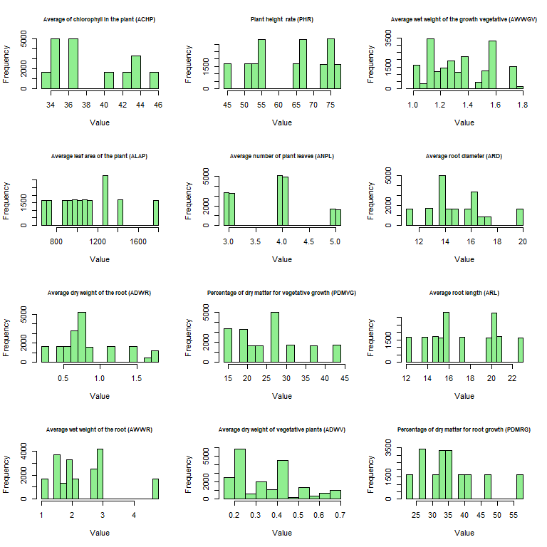

Distributions of predictors.

As we can see from the graphs, the 12 predictors do not seem to follow a Normal distribution. The majority of the variables seem to have skewness and multimodality. In particular, AWWGV, ADWR, AWWR and ADWV seem to be skewed. Instead, PHR, ALAP, and ARD presents more than one modality, suggesting that maybe there are different groups within the data, and this is confirm by the fact that plants can be grouped by the type of greenhouse or by the variety. Based on this evaluation, we need to transform data properly before applying statistical models.

After this analysis, we can have a look at the correlations between the variables, to better understand their relationships. From the correlation matrix (Figure 2) we can notice that, in general, we have more positive correlations (signed in blue tonalities). In particular we can see that there is a very strong positive relation of 0.95 between Average wet weight of the root (AWWR) and Average root diameter (ARD). This suggests that plants with thicker roots also tend to have heavier, water-rich roots. It is logical since thicker roots typically have more tissue capable of storing water and nutrients, contributing to a higher wet weight. Similar it is for the relation between Average dry weight of vegetative plants (ADWV) and Percentage of dry matter for vegetative growth (PDMVG) that have a correlation of 0.91. This makes sense since higher dry matter content means more structural biomass, leading to increased dry weight. Finally also a moderate, but still high, correlation of 0.81 between Average dry weight of the root (ADWR) and Average number of plant leaves (ANPL). Regarding the negative ones, we can say that there are less and weaker negative correlations (signed in red) for the majority, and from the graph we can notice that the variable Average of chlorophyll in the plant (ACHP) is the one that exposes this aspect the most. In particular, there is an high negative correlation of -0.75 between this variable and Average root length (ARL). These aspects regarding the variable ACHP suggests that plants probably tend to optimize for photosynthesis over root and leaf development. All the values of the correlation matrix are shown in the Appendix.

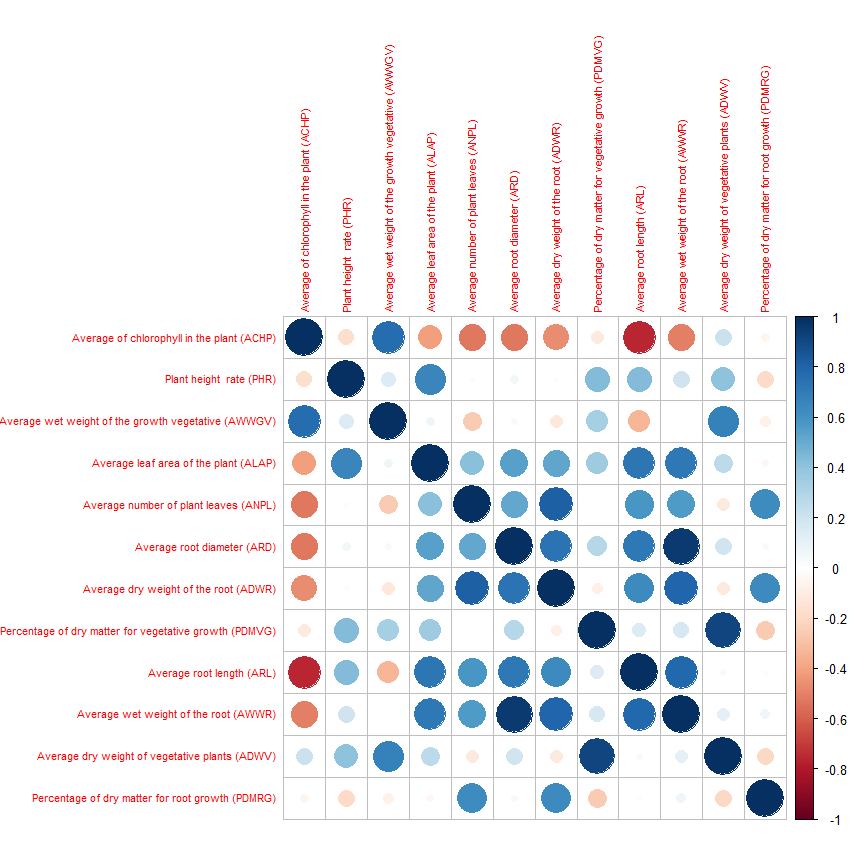

Corrplot.

Moreover, we have a look also at the variances of the predictors.

Variances of Predictors.

| Variable | Variance |
| --- | --- |
| Average of chlorophyll in the plant (ACHP) | 18.374 |
| Plant height rate (PHR) | 104.988 |
| Average wet weight of the growth vegetative (AWWGV) | 0.045 |
| Average leaf area of the plant (ALAP) | 84714.087 |
| Average number of plant leaves (ANPL) | 0.470 |
| Average root diameter (ARD) | 4.627 |
| Average dry weight of the root (ADWR) | 0.152 |
| Percentage of dry matter for vegetative growth (PDMVG) | 71.706 |
| Average root length (ARL) | 9.907 |
| Average wet weight of the root (AWWR) | 0.869 |
| Average dry weight of vegetative plants (ADWV) | 0.021 |
| Percentage of dry matter for root growth (PDMRG) | 79.284 |

From the results shown in Table 1, we can see that the variable with the highest spread is Average leaf area of the plant (ALAP), instead the lowest one belongs to the variable Average dry weight of vegetative plants (ADWV). The extremely high variance of the predictor ALAP, highlights a wide range in leaf area among all the plants, suggesting significant variability in the plants’ capacity for photosynthesis. This reflects also the slight variance of Average of chlorophyll in the plant (ACHP) that evokes the different efficiency at photosynthesis between plants. Probably these are consequences of the variety and the environment of each radish. In general variables with high variance are likely to play a significant role in distinguishing the classes, while predictors with low variance (in particular close to 0), influence less and suggest a relatively uniformity across plants for those specific aspects.

Before applying a statistical model, we need to operate the standardization to the data, to ensure that all variables contribute equally to the analysis. The standardized distributions are shown in Figure 3, and intuitively we can see that the standardization did not change the shapes of the distributions a lot.

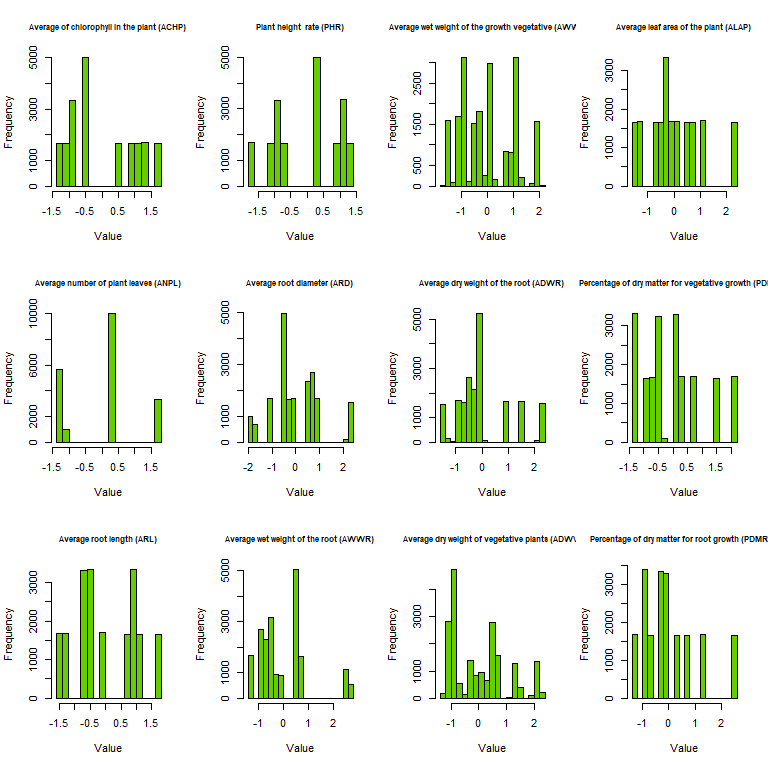

Distributions of standardized predictors.

As the last step of the Exploratory data analysis, we need to take a look to the distribution of the variable Class that is the target variable in our models. The graph obtained is shown in Figure 4 and as it is evident, the categories are totally balanced: there are exactly 5000 observations for each of the 4 classes. This aspect is quite important for the selection of a sample to apply the models, and this will be done in the next sections.

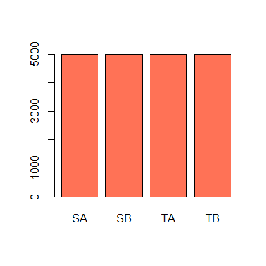

Distribution of the variable Class.

# 2. Data adjustment and sample selection

## 2.1 . Preparation of data on the target variable

Before applying any model, the variable Class is transformed in factors. Moreover they are also created two new variables named Env and Variety. The first one is used to divide the plants in two groups based on the greenhouse: Smart (S) codified in 1 and Traditional (T) in 2. This variable will be useful for the application of the second Bayesian model in the next sections. The second variable instead, represents the varieties of the plants codified in 1 for A variety and 2 for B. Furthermore, not to lose the original category assigned, a new column called Class.chr where to save the class before the factorization, is added. The final dataset is shown below.

```
'data.frame':   20000 obs. of  16 variables:
 $ Average of chlorophyll in the plant (ACHP)            : num  34.5 34.5 33.1 34.5 36.3 ...
 $ Plant height  rate (PHR)                              : num  54.6 54.6 67.1 54.6 45.6 ...
 $ Average wet weight of the growth vegetative (AWWGV)   : num  1.15 1.15 1.1 1.14 1.36 ...
 $ Average leaf area of the plant (ALAP)                 : num  1284 1284 1009 1284 981 ...
 $ Average number of plant leaves (ANPL)                 : num  5 5.02 5.01 4.99 4 ...
 $ Average root diameter (ARD)                           : num  16.3 16.3 16 16.3 17 ...
 $ Average dry weight of the root (ADWR)                 : num  1.707 1.701 1.185 1.716 0.777 ...
 $ Percentage of dry matter for vegetative growth (PDMVG): num  18.4 18.4 19.4 18.4 31.4 ...
 $ Average root length (ARL)                             : num  19.7 19.8 20.8 19.7 17.3 ...
 $ Average wet weight of the root (AWWR)                 : num  2.95 2.94 2.86 2.95 2.77 ...
 $ Average dry weight of vegetative plants (ADWV)        : num  0.209 0.216 0.2 0.223 0.424 ...
 $ Percentage of dry matter for root growth (PDMRG)      : num  57.6 57.6 41.3 57.6 27.9 ...
 $ Class                                                 : num  1 1 1 1 1 1 1 1 1 1 ...
 $ Class.chr                                             : chr  "SA" "SA" "SA" "SA" ...
 $ Env                                                   : num  1 1 1 1 1 1 1 1 1 1 ...
 $ Variety                                               : num  1 1 1 1 1 1 1 1 1 1 ...
```

## 2.2. Multicollinearity analysis

In section 1.3. we discussed about the correlation matrix and we saw that there was a majority of positive correlations between variables which, in some cases, were also quite strong. This could cause multicollinearity and for this reason we need to verify it. To do this, we can use a quantitative method: the Variance Inflation Factor (VIF). It measures how much variance of a predictor is explained by the other ones of the model. If the VIF is high, usually more than 10, this means that the specific variable interested is largely collinear with the others, and this can cause problems in the model.

As shown in Table 2, the VIF is really high for many predictors. The common technique in this situation is to remove variables that cause collinearity and that usually have high values of VIF. In this specific case, after the elimination of the four variables Average wet weight of the growth vegetative (AWWGV), Average root diameter (ARD), Average dry weight of the root (ADWR) and Average dry weight of vegetative plants (ADWV), we reach acceptable levels of VIF, as shown in Table 3. It is interesting to notice that the waviable Average wet weight of the root (AWWR) that had the highest initial value of VIF, has now a very low value of 4.68, since the variables with high correlation with it were removed.

Variance Inflation Factor.

| Variable | VIF |
| --- | --- |
| `Average of chlorophyll in the plant (ACHP)` | 28.528827 |
| `Plant height rate (PHR)` | 8.617544 |
| `Average wet weight of the growth vegetative (AWWGV)` | 74.076321 |
| `Average leaf area of the plant (ALAP)` | 15.776321 |
| `Average number of plant leaves (ANPL)` | 6.769150 |
| `Average root diameter (ARD)` | 129.235343 |
| `Average dry weight of the root (ADWR)` | 119.778746 |
| `Percentage of dry matter for vegetative growth (PDMVG)` | 99.602179 |
| `Average root length (ARL)` | 15.369452 |
| `Average wet weight of the root (AWWR)` | 187.243698 |
| `Average dry weight of vegetative plants (ADWV)` | 172.968515 |
| `Percentage of dry matter for root growth (PDMRG)` | 40.547827 |

| Variable | VIF |
| --- | --- |
| `Average of chlorophyll in the plant (ACHP)` | 3.038063 |
| `Plant height rate (PHR)` | 3.342139 |
| `Average leaf area of the plant (ALAP)` | 4.707537 |
| `Average number of plant leaves (ANPL)` | 4.699092 |
| `Percentage of dry matter for vegetative growth (PDMVG)` | 1.566452 |
| `Average root length (ARL)` | 9.300580 |
| `Average wet weight of the root (AWWR)` | 4.675711 |
| `Percentage of dry matter for root growth (PDMRG)` | 2.956939 |

## 2.3. Selection of a sample from data

Applying Bayesian models to the entire dataset of 20000 observations can be computationally intensive and time expensive. For this reason, it is necessary to reduce the sample size to a manageable one. As specified in section 1.3., our target variable Class has 5000 observation for every category. To ensure the representativeness of the data, a suitable proposal is to take 150 observations for each class (600 observations in total). For this specific case, to avoid class imbalance and to reflect the original dataset, **stratified sampling** seems to be an appropriate technique, since it allows to maintain the proportionality of each class within the sample. To operate this sampling method, it was used the function *createDataPartition* from the library *caret*, to obtain an index to extract the sample from the initial dataset. It is important to specify that, as explained in the mentioned section, we need to use standardize predictors before applying models, even if we use a restricted sample.

```r
#Selection of a sample through stratification
size <- 150 #Sample size for each class
#Index of stratification based on variable Class
idx <- createDataPartition(data$Class, p = size/5000,
                           #p = size/5000 specifies the ratio of
                           #observations to select from the total of
                           #each class (i.e. 3%)
                           list = FALSE, times = 1)
#Stratified sample
data.sampled <- data[idx, ]

#Check of sizes
check <- table(data.sampled$Class) #check of 150 for each one
str(data.sampled) #600x16
```

```
'data.frame':   600 obs. of  16 variables:
 $ Average of chlorophyll in the plant (ACHP)            : num  34.5 36.3 36.3 36.3 33.1 ...
 $ Plant height  rate (PHR)                              : num  54.6 45.6 45.6 45.6 67.1 ...
 $ Average wet weight of the growth vegetative (AWWGV)   : num  1.14 1.37 1.37 1.37 1.11 ...
 $ Average leaf area of the plant (ALAP)                 : num  1284 981 981 981 1009 ...
 $ Average number of plant leaves (ANPL)                 : num  4.99 4.01 4 4 5.01 ...
 $ Average root diameter (ARD)                           : num  16.3 17 17 17 16 ...
 $ Average dry weight of the root (ADWR)                 : num  1.704 0.773 0.791 0.766 1.188 ...
 $ Percentage of dry matter for vegetative growth (PDMVG): num  18.4 31.4 31.4 31.4 19.4 ...
 $ Average root length (ARL)                             : num  19.7 17.3 17.3 17.3 20.8 ...
 $ Average wet weight of the root (AWWR)                 : num  2.96 2.77 2.78 2.75 2.86 ...
 $ Average dry weight of vegetative plants (ADWV)        : num  0.226 0.417 0.401 0.434 0.201 ...
 $ Percentage of dry matter for root growth (PDMRG)      : num  57.6 27.9 27.9 27.9 41.3 ...
 $ Class                                                 : num  1 1 1 1 1 1 1 1 1 1 ...
 $ Class.chr                                             : chr  "SA" "SA" "SA" "SA" ...
 $ Env                                                   : num  1 1 1 1 1 1 1 1 1 1 ...
 $ Variety                                               : num  1 1 1 1 1 1 1 1 1 1 ...
```

```r
#Standardization of data sampled
sampled_standardized_predictors <- predict(preProcValues, data.sampled[, c(1:12)])
```

# 3. First Bayesian model: Multinomial logistic regression model

## 3.1. Formulation of the model

Having a problem of multiclass classification, the first and immediate model to apply is the Multinomial logistic regression one. This model is a natural extension of the Binomial logistic regression model and it is used when the target variable has more than 2 categories, which don’t have a specific order. It can be applied if there is no multicollinearity between independent variables and the classes of the response variable are mutually exclusive and exhaustive. The target variable $Y_i=(Y_{i1},...,Y_{iK})$ with $Y_{ik}$ representing the frequency of the $k^{th}$ level, is assumed to have $K$ levels. The model can be expressed in the following way:
$$Y_i \sim multinomial(\pi_i, N_i)$$
and
$$\log ( \frac{\pi_{ik}}{\pi_{i1}}) = \eta_{ik} = \beta_{0k} +
\sum^{k}_{i=1} \beta_{jk} x_{ij}, \quad (3.1)$$
for $k=2,...,K$, where $pi_i = (\pi_{i1},\pi_{i2},...,\pi_{iK})^T$ is the vector of the probabilities for every level of the variable $Y$ for individual $i$ (the probability that the plant $i$ belongs to category $k$), with $\pi_{i1} = 1-\sum^K_{k=2} \pi_{ik}$.

In terms of response probabilities, solving the (3.1), we have that:
$$\pi_{i1} = \frac{1}{1+\sum^K_{k=2} e^{\eta_{ik}}}$$
and also
$$\pi_{ik} = \frac{e^{\eta_{ik}}}{1+\sum^K_{k=2} e^{\eta_{ik}}}$$
for $k=2,...,K.$ The resulting summarizing term is:
$$\pi_{ik} = \frac{e^{\eta_{ik}}}{\sum^K_{k=1} e^{\eta_{ik}}}$$
with $\eta_{i1}=0$ for $i=1,2,...,n.$

## 3.2. Application of the model

In our case, since we removed four variables cause of multicollinearity, we can apply the **Multinomial logistic regression model**. This model can be implemented in JAGS in the following way:

```
\begin{verbatim}
model {
  #Likelihood
  for (i in 1:N) {
    y[i] ~ dcat(pi[i, 1:K])

    for (k in 1:K) {
      eta[i, k] <- beta0[k] +
                   beta[1, k] * ACHP[i] +
                   beta[2, k] * PHR[i] +
                   beta[3, k] * ALAP[i] +
                   beta[4, k] * ANPL[i] +
                   beta[5, k] * PDMVG[i] +
                   beta[6, k] * ARL[i] +
                   beta[7, k] * AWWR[i] +
                   beta[8, k] * PDMRG[i]

      expeta[i, k] <- exp(eta[i, k])
    }

    for (k in 1:K) {
      pi[i, k] <- expeta[i, k] / sum(expeta[i, ])
    }
  }

  #Priors
  for (k in 1:K){
    beta0[k] ~ dnorm(0, 0.1)

    #Predictors
    for (j in 1:8){
      beta[j, k] ~ dnorm(0, 0.1)
    }
  }
}
\end{verbatim}
```

and the commands in R are the following:

```r
# First Bayesian model: Multinomial logistic
# model
y <- as.numeric(data.sampled$Class)
K <- length(unique(y))  #4, number of classes

# MCMC
S <- 10000
burn_in <- 2000

data.prepared <- list(y = y, ACHP = sampled_standardized_predictors$`Average of chlorophyll in the plant (ACHP)`,
    PHR = sampled_standardized_predictors$`Plant height  rate (PHR)`,
    ALAP = sampled_standardized_predictors$`Average leaf area of the plant (ALAP)`,
    ANPL = sampled_standardized_predictors$`Average number of plant leaves (ANPL)`,
    PDMVG = sampled_standardized_predictors$`Percentage of dry matter for vegetative growth (PDMVG)`,
    ARL = sampled_standardized_predictors$`Average root length (ARL)`,
    AWWR = sampled_standardized_predictors$`Average wet weight of the root (AWWR)`,
    PDMRG = sampled_standardized_predictors$`Percentage of dry matter for root growth (PDMRG)`,
    N = nrow(sampled_standardized_predictors), K = K)

params <- c("beta0", "beta")

inits <- list(inits1 = list(beta0 = rep(0, K), beta = matrix(0,
    8, K)), inits2 = list(beta0 = rep(1, K), beta = matrix(1,
    8, K)), inits3 = list(beta0 = rep(-0.5, K), beta = matrix(-0.5,
    8, K)))

start.time1 <- Sys.time()

jags.1 <- jags(data = data.prepared, inits = inits,
    parameters.to.save = params, model.file = "C:\\Users\\sofyc\\OneDrive\\Desktop\\SAPIENZA\\SDS II\\project\\mod_agr.txt",
    n.chains = 3, n.iter = S, n.burnin = burn_in)
end.time1 <- Sys.time()
```

## 3.3. Convergence diagnostics and inferential findings

The time execution for this model is:

```
Time difference of 18.6473 mins
```

The first technique we use for diagnostic is represented by traceplots. They show the tendency of the samples for each parameter. In our case we have 36 traceplots since the model has 4 intercepts beta0 and 8 parameters beta for each of the 4 categories. Traceplots are displayed in Figure 5 and they show a good mix of the three chains of the model, exploring the entire parameter space. In these plots the firt chain is colored in red, the second in green and the third one in light blue.

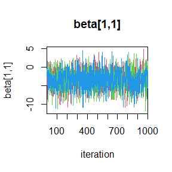

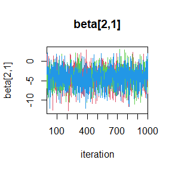

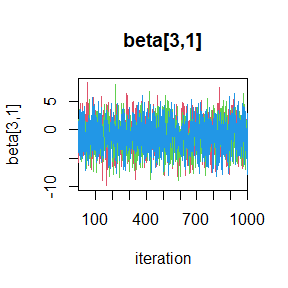

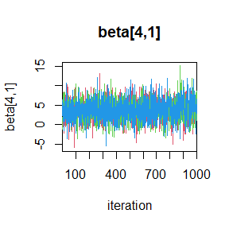

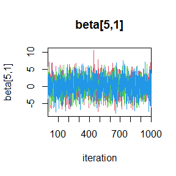

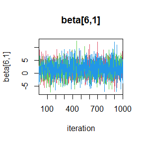

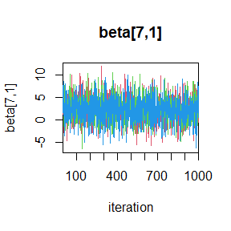

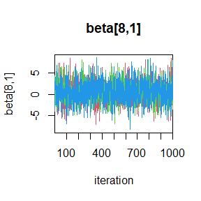

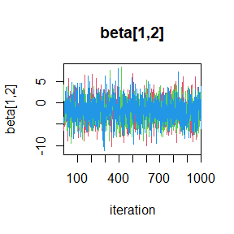

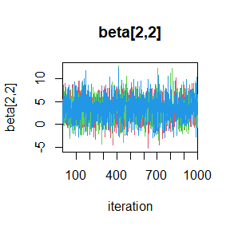

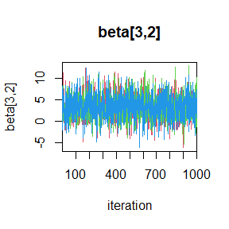

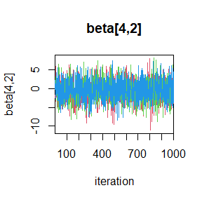

[24 more figures not shown]

```r
# Summary trace plots parameters (beta for each
# class and beta0 for each class) - of type
# beta[i, class] and beta0[class]
traceplot(jags.1, varname = c("beta"), ask = FALSE,
    col = c(2, 3, 4), match.head = FALSE)
# COLORS: 2=red, 3=green, 4=light blue
```

```
  acf(jags.1$BUGSoutput$sims.array[,1,parameter])
```

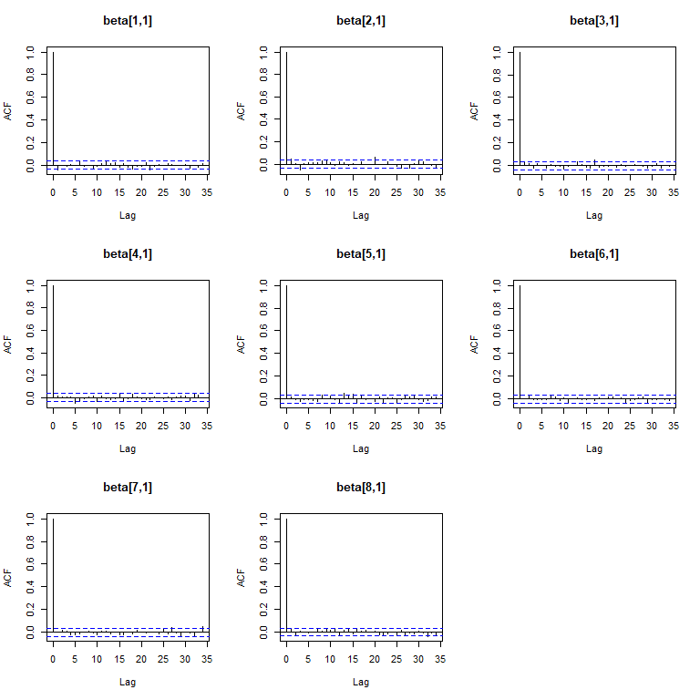

ACF plots beta - First class SA, First model.

```r
# Summary plot acf
par(mfrow = c(3, 3))
for (i in 1:8) {
    acf(jags.1$BUGSoutput$sims.matrix[, paste0("beta[",
        i, ",", 1, "]")], main = paste0("beta[", i,
        ",", 1, "]"))
}
par(mfrow = c(1, 1))
```

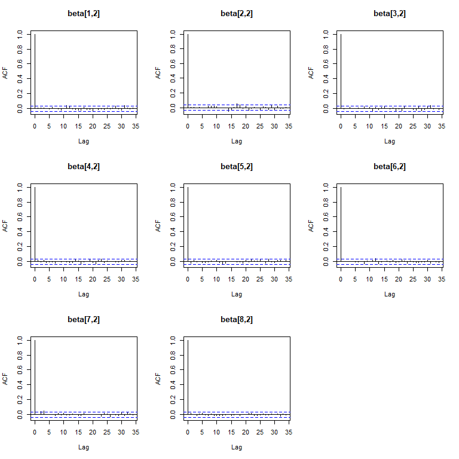

ACF plots beta - Second class SB, First model.

```r
# Summary plot acf
par(mfrow = c(3, 3))
for (i in 1:8) {
    acf(jags.1$BUGSoutput$sims.matrix[, paste0("beta[",
        i, ",", 2, "]")], main = paste0("beta[", i,
        ",", 2, "]"))
}
par(mfrow = c(1, 1))
```

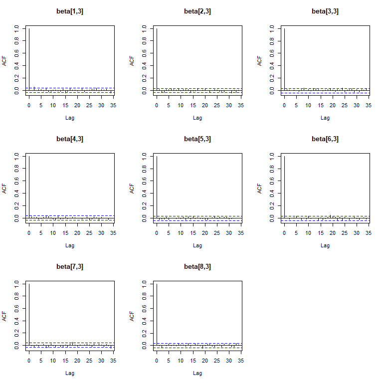

ACF plots beta - Third class TA, First model.

```r
# Summary plot acf
par(mfrow = c(3, 3))
for (i in 1:8) {
    acf(jags.1$BUGSoutput$sims.matrix[, paste0("beta[",
        i, ",", 3, "]")], main = paste0("beta[", i,
        ",", 3, "]"))
}
par(mfrow = c(1, 1))
```

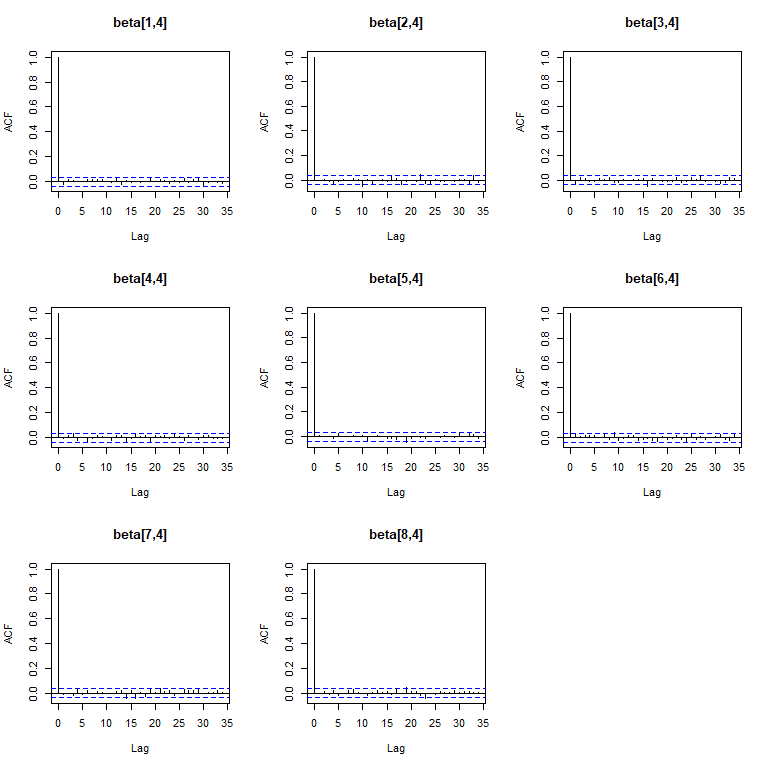

ACF plots beta - Fourth class TB, First model.

```r
# Summary plot acf
par(mfrow = c(3, 3))
for (i in 1:8) {
    acf(jags.1$BUGSoutput$sims.matrix[, paste0("beta[",
        i, ",", 4, "]")], main = paste0("beta[", i,
        ",", 4, "]"))
}
par(mfrow = c(1, 1))
```

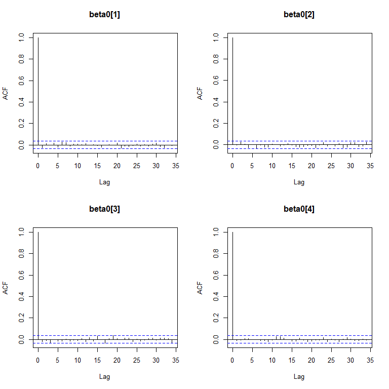

ACF plots intercept, First model.

```r
# Summary plot acf
par(mfrow = c(2, 2))
for (i in 1:4) {
    acf(jags.1$BUGSoutput$sims.matrix[, paste0("beta0[",
        i, "]")], main = paste0("beta0[", i, "]"))
}
```

```r
par(mfrow = c(1, 1))
```

Now we can look at the estimates of the parameters of the first model, and analyze its inference. The summaries of the First model are shown in Table 4 and 5. In Table 4 there are the summaries for the parameters *beta0* (for every class), and in Table 5 there are the summaries for the eight parameters *beta* (each for every class). The columns 2.5% and 97.5% represent the limits of the confidence interval at level $\alpha=0.05.$ These intervals show an high level of variability, for example for beta[8,2]. Also, some of them as for example beta[5,1], beta[7,3], beta[8,4], have a mean very close to 0, so for these parameters it is not possible to exclude the null effect. From the results of Table 5 of beta, we can also observe that plants with high value of Average of chlorophyll in the plant (ACHP), with parameter beta[1,k], are likely to belong to classes 3 (TA) and 4 (TB), i.e. to the Traditional greenhouse. Instead, plants with high Average root length (ARL), i.e. beta[6,k], and Average wet weight of the root (AWWR), i.e. beta[7,k], are likely to belong to the first two classes (Smart greenhouse). Regarding some possible interpretations for differences in varieties, we can see that plants of Syrian variety (B) probably have higher values of Plant height rate (PHR), i.e. beta[2,k], and Average leaf area of the plant (ALAP), i.e. beta[3,k], but also a likely lower value of Percentage of dry matter for root growth (PDMRG), i.e. beta[8,k], compared to the Dutch variety (A). From the results of Table 4 of beta0, we can see that the intercept for class 2 and 4 is really close to 0, and in general for each class beta0 has a high variability. Practically, since also the other intercept have an estimated mean of less than 1, this means that when all the predictors are 0, there is not so much difference between classes.

```r
# Extracting estimates and quantiles of beta0 and
# beta
summary.jags1.beta0 <- as.data.frame(jags.1$BUGSoutput$summary[grep("beta0",
    rownames(jags.1$BUGSoutput$summary)), ][, c(1:3,
    5, 7:9)])
summary.jags1.beta0 <- round(summary.jags1.beta0, 2)
# Table 4 beta0
kable(summary.jags1.beta0, caption = "First Bayesian model analysis and inference of beta0.",
    align = "c")
```

First Bayesian model analysis and inference of beta0.

|  | mean | sd | 2.5% | 50% | 97.5% | Rhat | n.eff |
| --- | --- | --- | --- | --- | --- | --- | --- |
| beta0[1] | 0.67 | 2.45 | -4.18 | 0.71 | 5.40 | 1.00 | 2000 |
| beta0[2] | 0.09 | 2.62 | -5.15 | 0.17 | 5.00 | 1.00 | 1900 |
| beta0[3] | -0.71 | 2.61 | -5.96 | -0.71 | 4.17 | 1.00 | 820 |
| beta0[4] | -0.18 | 2.49 | -5.15 | -0.15 | 4.64 | 1.01 | 390 |

```r
# Extracting estimates and quantiles of beta
summary.jags1.beta <- as.data.frame(jags.1$BUGSoutput$summary[grep("^beta\\[",
    rownames(jags.1$BUGSoutput$summary)), ][, c(1:3,
    5, 7:9)])
summary.jags1.beta <- round(summary.jags1.beta, 2)
# Table 5 beta
kable(summary.jags1.beta, caption = "First Bayesian model analysis and inference of beta.",
    align = "c")
```

First Bayesian model analysis and inference of beta.

|  | mean | sd | 2.5% | 50% | 97.5% | Rhat | n.eff |
| --- | --- | --- | --- | --- | --- | --- | --- |
| beta[1,1] | -3.33 | 2.46 | -8.35 | -3.24 | 1.34 | 1.00 | 3000 |
| beta[2,1] | -4.27 | 2.40 | -9.12 | -4.21 | 0.34 | 1.00 | 1500 |
| beta[3,1] | -1.02 | 2.76 | -6.47 | -1.04 | 4.32 | 1.00 | 1100 |
| beta[4,1] | 3.84 | 2.65 | -1.38 | 3.87 | 8.99 | 1.00 | 3000 |
| beta[5,1] | 0.21 | 2.60 | -5.06 | 0.24 | 5.24 | 1.00 | 3000 |
| beta[6,1] | 1.56 | 2.84 | -3.96 | 1.54 | 7.01 | 1.00 | 1400 |
| beta[7,1] | 2.20 | 2.66 | -3.06 | 2.16 | 7.50 | 1.00 | 3000 |
| beta[8,1] | 0.65 | 2.53 | -4.20 | 0.63 | 5.69 | 1.00 | 1800 |
| beta[1,2] | -1.81 | 2.74 | -7.18 | -1.77 | 3.50 | 1.00 | 1700 |
| beta[2,2] | 3.41 | 2.55 | -1.51 | 3.40 | 8.43 | 1.00 | 840 |
| beta[3,2] | 3.35 | 2.74 | -1.91 | 3.33 | 8.78 | 1.00 | 1800 |
| beta[4,2] | -0.47 | 2.69 | -5.72 | -0.43 | 4.85 | 1.00 | 2100 |
| beta[5,2] | 1.90 | 2.48 | -2.74 | 1.86 | 7.01 | 1.00 | 3000 |
| beta[6,2] | 2.68 | 2.77 | -2.81 | 2.70 | 7.99 | 1.00 | 3000 |
| beta[7,2] | 0.93 | 2.60 | -4.16 | 0.94 | 5.95 | 1.00 | 3000 |
| beta[8,2] | -1.31 | 2.67 | -6.64 | -1.23 | 3.83 | 1.00 | 3000 |
| beta[1,3] | 1.56 | 2.14 | -2.56 | 1.55 | 5.77 | 1.00 | 1800 |
| beta[2,3] | -3.05 | 2.31 | -7.55 | -3.07 | 1.37 | 1.01 | 300 |
| beta[3,3] | -4.53 | 2.64 | -9.54 | -4.57 | 0.84 | 1.00 | 1600 |
| beta[4,3] | -1.42 | 2.61 | -6.43 | -1.44 | 3.81 | 1.00 | 3000 |
| beta[5,3] | -2.44 | 2.52 | -7.27 | -2.40 | 2.31 | 1.00 | 3000 |
| beta[6,3] | -1.40 | 2.59 | -6.45 | -1.47 | 3.75 | 1.00 | 550 |
| beta[7,3] | -0.14 | 2.87 | -5.96 | -0.15 | 5.38 | 1.00 | 3000 |
| beta[8,3] | 0.74 | 2.42 | -4.13 | 0.79 | 5.45 | 1.00 | 3000 |
| beta[1,4] | 3.73 | 2.21 | -0.46 | 3.75 | 8.09 | 1.00 | 2400 |
| beta[2,4] | 4.10 | 2.57 | -0.89 | 4.12 | 8.96 | 1.00 | 3000 |
| beta[3,4] | 2.25 | 2.75 | -3.22 | 2.27 | 7.54 | 1.00 | 1100 |
| beta[4,4] | -2.13 | 2.70 | -7.48 | -2.09 | 3.19 | 1.00 | 3000 |
| beta[5,4] | 0.37 | 2.49 | -4.49 | 0.40 | 5.30 | 1.00 | 1600 |
| beta[6,4] | -3.06 | 2.60 | -8.20 | -3.02 | 1.95 | 1.00 | 3000 |
| beta[7,4] | -3.12 | 2.81 | -8.81 | -3.03 | 2.37 | 1.00 | 2300 |
| beta[8,4] | -0.04 | 2.55 | -5.04 | -0.04 | 5.03 | 1.00 | 2100 |

The last column is instead **n.eff**. This column represents the **Effective Sample Size (ESS)**, another method for the diagnostic of a Bayesian model. It is a measure that evaluates the quality of the samples generated by MCMC sampling and it gives the number of independent and identically distributed samples produced, despite they are correlated due to temporal dependency. It can be expressed by
$$ESS = \frac{N}{1+2 \sum_{k=1}^\infty \rho_k}$$
where $N$ is the number of total samples and $\rho_k$ is the autocorrelation at lag $k$. The more the autocorrelation between samples, the lower ESS will be compared to the real dimension of the samples $N$.

Now, let’s look at the parameter’s distribution. We can extract the information in this way:

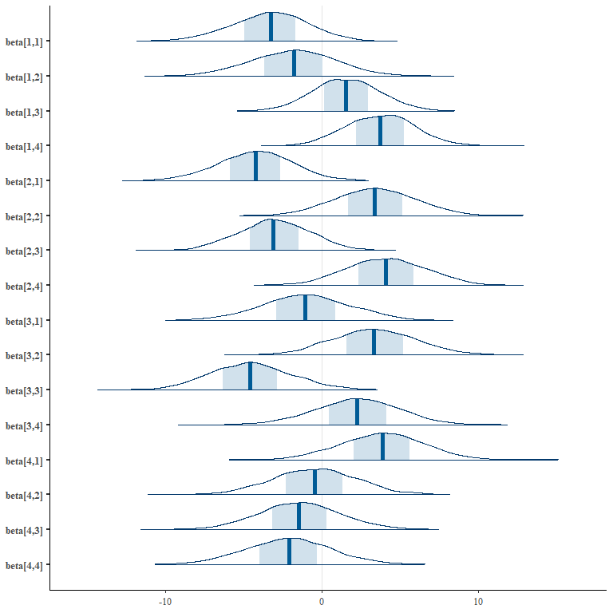

Posterior Distributions of beta, First model.

```r
# beta - Fig.11
mcmc.jags1 <- as.mcmc(jags.1)
mcmc_areas(mcmc.jags1, pars = c("beta[1,1]", "beta[1,2]",
    "beta[1,3]", "beta[1,4]", "beta[2,1]", "beta[2,2]",
    "beta[2,3]", "beta[2,4]", "beta[3,1]", "beta[3,2]",
    "beta[3,3]", "beta[3,4]", "beta[4,1]", "beta[4,2]",
    "beta[4,3]", "beta[4,4]"))
```

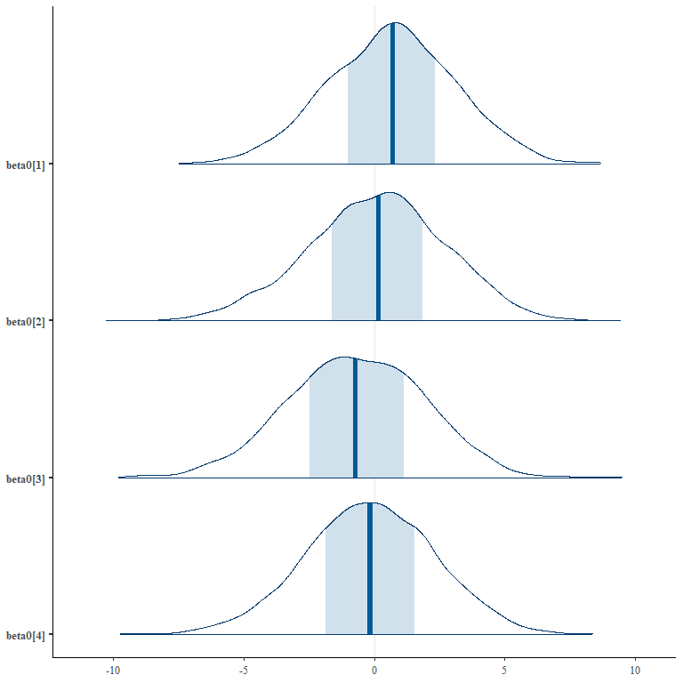

Posterior Distributions of beta0, First model.

```r
# beta0 - Fig. 12
mcmc_areas(mcmc.jags1, pars = c("beta0[1]", "beta0[2]",
    "beta0[3]", "beta0[4]"))
```

As we can see the distributions seem symmetric and this is a good sign of convergence, even if the distributions have high variability. Moreover, the parameters beta[4,2] has a mean very close to zero, suggesting that it can be not significant. Same situation for the intercepts beta0[2] and beta0[4], as we have already noticed also by Tables 4 and 5 of parameters’ estimates.

Continuing with the diagnostic, another important measure to look at is the **Monte Carlo Standard Error (MCSE)** that quantifies the uncertainty of the estimate of Monte Carlo simulation. It is the residual variability of the estimate due to the sampling, taking into account the autocorrelation. Basically, it measures how much an estimate obtained from MCMC simulation could vary from a simulation to another and, in this sense, it is an indicator of precision of the estimate of a quantity or the parameter of interest. If there was not autocorrelation between samples, MCSE would be equal to the Standard Error
$$SE = \frac{\sigma}{\sqrt N}$$
where $\sigma$ is the sampling standard deviation, and $N$ is the dimension of the sample. Due to autocorrelation, we have a reduction in the *Effective number of samples* as explained before, then the MCSE is defined as:
$$MCSE = \frac{\hat \sigma}{\sqrt ESS}.$$
We interpret a low MCSE as a more precise estimate for that parameter. Also, if ESS is too low, MCSE will be higher meaning that the estimates of the model are not accurate. This could suggest that the chain does not converge.

```r
mcse.jags1 <- list()
# MCSE for beta0
mcse.jags1$beta0 <- lapply(1:3, function(mc) {
    sapply(1:4, function(class) {
        # Extract samples of beta0 for the chain
        # mc and the category class
        param.name <- paste0("beta0[", class, "]")
        MCSE(jags.1$BUGSoutput$sims.array[, mc, param.name])
    })
})

# MCSE for beta (8 parameters for 4 classes)
mcse.jags1$beta <- lapply(1:3, function(mc) {
    sapply(1:4, function(class) {
        sapply(1:8, function(coef) {
            # Extract samples of beta for the
            # chain mc and the category class
            param.name <- paste0("beta[", coef, ",",
                class, "]")
            MCSE(jags.1$BUGSoutput$sims.array[, mc,
                param.name])
        })
    })
})

# Results in 3 matrices (one per mc)
mcse.jags1$beta <- lapply(mcse.jags1$beta, function(beta.mc) {
    matrix(beta.mc, nrow = 8, ncol = 4)
})

# Show results
mcse.jags1
```

```
$beta0
$beta0[[1]]
[1] 0.1029925 0.1002628 0.1380075 0.1177316

$beta0[[2]]
[1] 0.09320065 0.09443793 0.13554549 0.10199904

$beta0[[3]]
[1] 0.08959609 0.08384003 0.13995976 0.11519911


$beta
$beta[[1]]
           [,1]       [,2]       [,3]       [,4]
[1,] 0.09535046 0.10889395 0.10545652 0.10528972
[2,] 0.10582112 0.11757580 0.11434082 0.12064407
[3,] 0.09221739 0.08957009 0.10131204 0.10572581
[4,] 0.09652237 0.09027923 0.10708929 0.11836464
[5,] 0.08564159 0.07804389 0.09240635 0.08900468
[6,] 0.09892830 0.09934398 0.12611501 0.12763821
[7,] 0.09535503 0.08647650 0.11017063 0.12612694
[8,] 0.08759592 0.08762816 0.09802955 0.10155594

$beta[[2]]
           [,1]       [,2]       [,3]       [,4]
[1,] 0.09342480 0.10382598 0.11303035 0.11069462
[2,] 0.10596248 0.08974524 0.09633362 0.10581470
[3,] 0.08971436 0.09643861 0.10077794 0.09993933
[4,] 0.09835679 0.08400938 0.12041149 0.11504458
[5,] 0.08218627 0.08465785 0.08878351 0.08088412
[6,] 0.10508709 0.11349216 0.10984520 0.12361884
[7,] 0.09171168 0.08280547 0.11595174 0.13636993
[8,] 0.07791461 0.08469640 0.09126735 0.09379496

$beta[[3]]
           [,1]       [,2]       [,3]       [,4]
[1,] 0.10756561 0.09884856 0.11233939 0.10473967
[2,] 0.11081333 0.09164913 0.09498779 0.09967614
[3,] 0.09323448 0.12077641 0.10843751 0.10406944
[4,] 0.10759431 0.08689978 0.11022894 0.11222361
[5,] 0.08536434 0.08677011 0.08501697 0.08266460
[6,] 0.10378273 0.10780878 0.11654672 0.13019343
[7,] 0.09581337 0.08780450 0.11872554 0.11192571
[8,] 0.09046812 0.09107016 0.09654955 0.09033340
```

**Geweke diagnostic** is instead a convergence diagnostic to evaluate if the chains have reached the stationarity. It is based on a test for the equality of the means of the first and last part of a Markov chain (by default the first 10% and the last 50%), to determine if the chain converged. In this sense it evaluates also if the sampling is representative, since if the samples are produced by the stationary distribution of the chain, the two means are equal. In this case the Geweke’s statistic has an asymptotically standard normal distribution. If the statistic Z is close to 0, the means of the two sections are similar and the chain converges. If Z is far away from 0, this suggests that the means are different and the chain could not converge. The Geweke test is calculated for each parameter. The results ar shown below:

```r
mcmc1.final <- mcmc.list(mcmc.jags1)
# Geweke diagnostic
(geweke.diag.jags1 <- geweke.diag(mcmc1.final))
```

```
[[1]]

Fraction in 1st window = 0.1
Fraction in 2nd window = 0.5

beta[1,1] beta[1,2] beta[1,3] beta[1,4] beta[2,1] beta[2,2]
 -0.73527  -1.11470  -1.96669  -0.96292   1.10708   0.92091
beta[2,3] beta[2,4] beta[3,1] beta[3,2] beta[3,3] beta[3,4]
 -0.41567   2.28789   1.29574   2.47290   2.99348  -0.85399
beta[4,1] beta[4,2] beta[4,3] beta[4,4] beta[5,1] beta[5,2]
  0.43900  -0.65912  -1.78431  -0.33722  -0.42407  -0.07358
beta[5,3] beta[5,4] beta[6,1] beta[6,2] beta[6,3] beta[6,4]
  1.59178   0.23246  -0.01546  -0.42844   0.69558   0.82304
beta[7,1] beta[7,2] beta[7,3] beta[7,4] beta[8,1] beta[8,2]
  0.76303   0.41007   0.99906  -0.38308  -0.93705  -1.02121
beta[8,3] beta[8,4]  beta0[1]  beta0[2]  beta0[3]  beta0[4]
 -0.60206  -1.71757   0.47794   1.03242   1.41992  -1.06825
 deviance
 -0.61133


[[2]]

Fraction in 1st window = 0.1
Fraction in 2nd window = 0.5

beta[1,1] beta[1,2] beta[1,3] beta[1,4] beta[2,1] beta[2,2]
  2.09935   0.86679   1.70411   0.20584  -1.24392  -1.00554
beta[2,3] beta[2,4] beta[3,1] beta[3,2] beta[3,3] beta[3,4]
 -1.22878   0.33719   0.25455  -1.00821   0.25592  -2.48728
beta[4,1] beta[4,2] beta[4,3] beta[4,4] beta[5,1] beta[5,2]
  1.37339   1.68749   1.28087   0.57622  -0.46762  -0.49075
beta[5,3] beta[5,4] beta[6,1] beta[6,2] beta[6,3] beta[6,4]
  0.54440  -1.10313  -0.03858  -0.23691   0.25424   0.28464
beta[7,1] beta[7,2] beta[7,3] beta[7,4] beta[8,1] beta[8,2]
  0.88962   0.23212  -0.33489   1.51429   0.50942   0.12780
beta[8,3] beta[8,4]  beta0[1]  beta0[2]  beta0[3]  beta0[4]
 -1.20700   0.45567   1.09915   1.79036  -0.21755   0.90116
 deviance
  0.34287


[[3]]

Fraction in 1st window = 0.1
Fraction in 2nd window = 0.5

beta[1,1] beta[1,2] beta[1,3] beta[1,4] beta[2,1] beta[2,2]
 -1.37290   1.96538  -1.51242  -1.66736   0.92685  -1.09409
beta[2,3] beta[2,4] beta[3,1] beta[3,2] beta[3,3] beta[3,4]
  1.66297   0.07797  -0.01935   0.44225  -0.26297  -0.69174
beta[4,1] beta[4,2] beta[4,3] beta[4,4] beta[5,1] beta[5,2]
 -2.64731   0.18963   1.56202  -1.83089  -1.37784   0.41149
beta[5,3] beta[5,4] beta[6,1] beta[6,2] beta[6,3] beta[6,4]
  1.57025   0.83020  -0.54226   0.56925  -0.66342   0.06663
beta[7,1] beta[7,2] beta[7,3] beta[7,4] beta[8,1] beta[8,2]
  1.32726   1.10627  -1.97767   0.15275   0.16701   1.49583
beta[8,3] beta[8,4]  beta0[1]  beta0[2]  beta0[3]  beta0[4]
 -0.95685   1.35857   0.14524   1.74142  -0.81314  -1.24719
 deviance
  0.81714
```

Going on, **Heidelberger-Welch Diagnostic** is a test with H0 which verifies that the sampled values comes from a stationary distributions. It works in this way: first it is applied to the whole chain, then after discarding the first 10%, 20%, of the chain until either the null hypothesis is accepted, or 50% of the chain has been discarded. If there are a lot of “failures” of the test, then a longer MCMC run is needed. The other test shown is the **Halfwidth Mean Test** and it is a test to measure the average length of an interval of the parameters, to evaluate the convergence. However, we take in consideration only the Stationarity tests. The results are shown below:

```r
# Heidelberger-Welch diagnostic
(heidel.diag.jags1 <- heidel.diag(mcmc1.final))
```

```
[[1]]

          Stationarity start     p-value
          test         iteration
beta[1,1] passed         1       0.3592
beta[1,2] passed         1       0.3972
beta[1,3] passed         1       0.0828
beta[1,4] passed         1       0.6928
beta[2,1] passed         1       0.3606
beta[2,2] passed         1       0.3503
beta[2,3] passed         1       0.5997
beta[2,4] passed         1       0.2215
beta[3,1] passed         1       0.7631
beta[3,2] passed       101       0.0655
beta[3,3] passed       101       0.1944
beta[3,4] passed         1       0.4024
beta[4,1] passed         1       0.9025
beta[4,2] passed         1       0.0988
beta[4,3] passed         1       0.7360
beta[4,4] passed         1       0.0654
beta[5,1] passed         1       0.2394
beta[5,2] passed         1       0.5696
beta[5,3] passed         1       0.6778
beta[5,4] passed         1       0.4062
beta[6,1] passed         1       0.2740
beta[6,2] passed         1       0.6877
beta[6,3] passed         1       0.5436
beta[6,4] passed         1       0.3403
beta[7,1] passed         1       0.1760
beta[7,2] passed         1       0.3068
beta[7,3] passed         1       0.6451
beta[7,4] passed         1       0.8744
beta[8,1] passed         1       0.8845
beta[8,2] passed         1       0.2273
beta[8,3] passed         1       0.0822
beta[8,4] passed         1       0.2523
beta0[1]  passed         1       0.9000
beta0[2]  passed         1       0.4776
beta0[3]  passed         1       0.5893
beta0[4]  passed         1       0.1045
```

[output cut: 190 more lines]

```
beta[6,3] failed    -1.5797 0.206
beta[6,4] passed    -3.0578 0.216
beta[7,1] passed     2.1737 0.164
beta[7,2] failed     0.9385 0.162
beta[7,3] failed    -0.1513 0.212
beta[7,4] passed    -3.0998 0.194
beta[8,1] failed     0.6772 0.162
beta[8,2] failed    -1.3198 0.163
beta[8,3] failed     0.6979 0.152
beta[8,4] failed    -0.1362 0.171
beta0[1]  failed     0.6988 0.167
beta0[2]  failed     0.2106 0.162
beta0[3]  failed    -0.6688 0.232
beta0[4]  failed     0.0511 0.198
deviance  passed     3.5229 0.160
```

As we can see, almost all passed the stationarity test, beside parameter beta[8,3] in the third chain.

The last diagnostic applied is **Raftery-Lewis** technique, used to calculate the necessary number of sampling MCMC to guarantee reliable estimates, and for the chain to be sufficiently convergent and representative of the posterior distribution. The idea is that if, for a specific parameter of interest $q$, we define an acceptable tolerance $r$ and a probability $s$ of being within that tolerance, this diagnostic will calculate the number of iterations $N$ and the number of burn-ins $M$ necessary to satisfy the specified conditions. This calculation is made with a 5% percentage of acceptable error, and
$$N \geq \frac{1}{(\hat \sigma^2 - \epsilon^2)} (\frac{1}{\epsilon}
(\frac{z_{\alpha/2}}{\sigma}))^2$$
where $\hat \sigma$ is the estimate of the standard deviation of the statistic of interest, $\sigma$ is its exact standard deviation, $\epsilon$ is the acceptable error and $z_{\alpha/2}$ is the quantile of the normal distribution.

The results for the First Bayesian model are shown below and for an accuracy of 0.005 and a percentage of error of 5%, we need at least 3746 iterations for each chain.

```r
# Raftery-Lewis Diagnostic diagnostic
(raftery.diag.jags1 <- raftery.diag(mcmc1.final))
```

```
[[1]]

Quantile (q) = 0.025
Accuracy (r) = +/- 0.005
Probability (s) = 0.95

You need a sample size of at least 3746 with these values of q, r and s

[[2]]

Quantile (q) = 0.025
Accuracy (r) = +/- 0.005
Probability (s) = 0.95

You need a sample size of at least 3746 with these values of q, r and s

[[3]]

Quantile (q) = 0.025
Accuracy (r) = +/- 0.005
Probability (s) = 0.95

You need a sample size of at least 3746 with these values of q, r and s
```

# 4. Second Bayesian model: Multilevel model with Hierarchical Random Terms

## 4.1. Formulation of the model

For the second model, we can formulate a two-levels model. The proposed one is a **Multilevel model with Hierarchical Random Terms**. It is basically a hierarchical multinomial regression model and, as before, it predicts a categorical response variable with $K$ categories, while also accounting for unobserved variability at different hierarchical levels through random effects. These two levels are the environment (also called greenhouse) and the varieties. The target variable, as in the previous Bayesian model, is $Y_i=(Y_{i1},...,Y_{iK})$ where $i$ is every plant observed. The model, again, can be expressed in the following way:
$$Y_i \sim multinomial(\pi_i, N_i)$$
with $\sum_{k=1}^{K} \pi_{ik} = 1$ and $\pi_{ik}$ the probability that plant $i$ belongs to category $k$. As in Multinomial logistic regression model, it is assumed that the probabilities of belonging to each category are determined by a linear combination of independent random variables $x_{ip}$ with $p=1,...,P$ and, for this case, also random effects at two levels (i.e. for environment and for variety). Hence, in this model we have that:
$$\log ( \frac{\pi_{ik}}{\pi_{i1}}) = \eta_{ik} = \sum_{i=1}^{P}
\beta_{pk} x_{ip} + u_{\textit{env}[j], k} + u_{\textit{variety}[j], k},
\quad (4.1)$$
where: - $\sum_{i=1}^{P} \beta_{pk} x_{ip}$ is the effect of the predictors weighted by their parameters, - $u_{\textit{env}[j], k}$ is the random effect of the environment $j$ for the class $k$ and it captures the variability between greenhouses, - $u_{\textit{variety}[j], k}$ is the random effect of the variety $j$ and it captures the variability between plant’s varieties.

Through the softmax function we have that:
$$\pi_{ik} = \frac{\exp(\eta_{ik})}{\sum_{k=1}^{K} \exp(\eta_{ik})}.$$

Moreover, the random effect for environment and for variety are assumed to follow Normal distributions with mean zero and unknown variances such that $u_{\text{env}[j],k} \sim N(0, \tau_{\text{env}})$ and $u_{\text{variety}[j],k} \sim N(0, \tau_{\text{variety}}).$

## 4.2. Application of the model

The model explained in section 4.1. can be implemented in JAGS in the following way:

```
\begin{verbatim}
model {
  for (i in 1:N) {
    y[i] ~ dcat(pi[i, 1:K])

    #Likelihood
    for (k in 1:K) {
      eta[i, k] <- beta[1, k] * ACHP[i] +
                   beta[2, k] * PHR[i] +
                   beta[3, k] * ALAP[i] +
                   beta[4, k] * ANPL[i] +
                   beta[5, k] * PDMVG[i] +
                   beta[6, k] * ARL[i] +
                   beta[7, k] * AWWR[i] +
                   beta[8, k] * PDMRG[i] +
                   u_env[environment[i], k]  #Random effect for environment
                  + u_variety[variety[i], k]  #Random effect for variety
      expeta[i, k] <- exp(eta[i, k])
    }

    for (k in 1:K) {
      pi[i, k] <- expeta[i, k] / sum(expeta[i, ])
    }
  }

  #Priors (beta for each predictor p and class k)
  for (p in 1:8) {  #8 predictors
    for (k in 1:K) {
      beta[p, k] ~ dnorm(0, 0.1)
    }
  }

  #Random effect for environment
  for (j in 1:2) {  #2 environments: S=1, T=0
    for (k in 1:K) {
      u_env[j, k] ~ dnorm(0, tau_env)
    }
  }
  tau_env ~ dgamma(0.1, 0.1)

  #Random effect for variety
  for (j in 1:2) {  #2 varieties: A, B
    for (k in 1:K) {
      u_variety[j, k] ~ dnorm(0, tau_variety)
    }
  }
  tau_variety ~ dgamma(0.1, 0.1)
}
\end{verbatim}
```

and the commands in R are the following:

```r
# Second Bayesian model: Multilevel model with
# Hierarchical Random Terms
y <- as.numeric(data.sampled$Class)
K <- length(unique(y))  #4, number of classes

# MCMC
S <- 10000
burn_in <- 2000

data.prepared <- list(y = y, ACHP = sampled_standardized_predictors$`Average of chlorophyll in the plant (ACHP)`,
    PHR = sampled_standardized_predictors$`Plant height  rate (PHR)`,
    ALAP = sampled_standardized_predictors$`Average leaf area of the plant (ALAP)`,
    ANPL = sampled_standardized_predictors$`Average number of plant leaves (ANPL)`,
    PDMVG = sampled_standardized_predictors$`Percentage of dry matter for vegetative growth (PDMVG)`,
    ARL = sampled_standardized_predictors$`Average root length (ARL)`,
    AWWR = sampled_standardized_predictors$`Average wet weight of the root (AWWR)`,
    PDMRG = sampled_standardized_predictors$`Percentage of dry matter for root growth (PDMRG)`,
    N = nrow(sampled_standardized_predictors), K = K,
    environment = as.numeric(data.sampled$Env), variety = as.numeric(data.sampled$Variety))

params <- c("beta", "u_env", "u_variety", "tau_env",
    "tau_variety")

inits <- list(inits1 = list(beta = matrix(0, 8, K),
    u_env = matrix(0, 2, K), u_variety = matrix(0,
        2, K), tau_env = 1, tau_variety = 1), inits2 = list(beta = matrix(1,
    8, K), u_env = matrix(1, 2, K), u_variety = matrix(1,
    2, K), tau_env = 1, tau_variety = 1), inits3 = list(beta = matrix(-0.5,
    8, K), u_env = matrix(-0.5, 2, K), u_variety = matrix(-0.5,
    2, K), tau_env = 1, tau_variety = 1))

start.time2 <- Sys.time()

jags.2 <- jags(data = data.prepared, inits = inits,
    parameters.to.save = params, model.file = "C:\\Users\\sofyc\\OneDrive\\Desktop\\SAPIENZA\\SDS II\\project\\mod_agr_multilevel_random.txt",
    n.chains = 3, n.iter = S, n.burnin = burn_in)
end.time2 <- Sys.time()
```